# Week11_2021_Mar9

Liam D. Bailey

09/03/2021

Set options

Load packages

```r
library(ggplot2)
library(dplyr)
library(fuzzyjoin)
```

Load TidyTuesday data

```r
tuesdata <- tidytuesdayR::tt_load(2021, week = 11)
```

```
## --- Compiling #TidyTuesday Information for 2021-03-09 ----
```

```
## --- There are 2 files available ---
```

```
## --- Starting Download ---
```

```
## --- Download complete ---
```

```r
bechdel <- tuesdata$raw_bechdel
movies  <- tuesdata$movies
```

Load the Jamee Bond data

```r
bond <- read.csv(here::here("./data/james_bond_movies.csv"))
```

Filter out just the james bond movies from the Bechdal test data

```r
bond_movies <- bond %>%
  fuzzyjoin::stringdist_left_join(bechdel, by = c("Movie" = "title")) %>%
  fuzzyjoin::stringdist_left_join(movies, by = c("Movie" = "title"))

#Add in the Living Daylights year so we get the right era block for Dalton
bond_movies$year.x[bond_movies$Movie == "The Living Daylights"] <- 1987

bond_movies <- bond_movies %>%
  #Remove old Casino Royale movie which is a 'spy parody'
  dplyr::filter(year.x != "1967") %>%
  dplyr::select(title = Movie, year = year.x, Actor, bond_rating = rating)

other_movies <- bechdel %>%
  dplyr::left_join(dplyr::select(movies, imdb_id, genre, language), by = "imdb_id") %>%
  fuzzyjoin::stringdist_anti_join(bond, by = c("title" = "Movie")) %>%
  dplyr::filter(year %in% bond_movies$year) %>%
  dplyr::group_by(year) %>%
  dplyr::summarise(all_movie_rating = mean(rating),
                   n = n()) %>%
  #Create a rolling mean
  dplyr::mutate(lag1 = lag(all_movie_rating),
                lead1 = lead(all_movie_rating)) %>%
  dplyr::rowwise() %>%
  dplyr::mutate(rollingmean_allmovies = mean(c(all_movie_rating, lag1, lead1))) %>%
  dplyr::select(-lag1, -lead1)

action_movies <- bechdel %>%
  dplyr::left_join(dplyr::select(movies, imdb_id, genre, language), by = "imdb_id") %>%
  fuzzyjoin::stringdist_anti_join(bond, by = c("title" = "Movie")) %>%
  dplyr::filter(year %in% bond_movies$year & stringr::str_detect(genre, "Action")) %>%
  dplyr::group_by(year) %>%
  dplyr::summarise(action_movie_rating = mean(rating)) %>%
  #Create a rolling mean
  dplyr::mutate(lag1 = lag(action_movie_rating),
                lead1 = lead(action_movie_rating)) %>%
  dplyr::rowwise() %>%
  dplyr::mutate(rollingmean_actionmovies = mean(c(action_movie_rating, lag1, lead1))) %>%
  dplyr::select(-lag1, -lead1)

combo_data <- other_movies %>%
  dplyr::left_join(action_movies, by = "year")
```

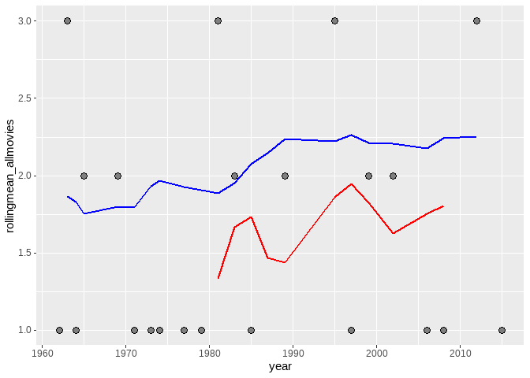

```r
ggplot() +
  geom_path(data = combo_data, aes(x = year, y = rollingmean_allmovies), size = 1, colour = "blue") +
  geom_path(data = combo_data, aes(x = year, y = rollingmean_actionmovies), size = 1, colour = "red") +
  geom_point(data = bond_movies, aes(x = year, y = bond_rating), size = 3, shape = 21, fill = "grey50")
```

```r
bond_eras <- bond_movies %>%
  mutate(era_nr = 1)

for(i in 1:nrow(bond_eras)){

  if (i == 1) {

    next()

  } else if (bond_eras$Actor[i] == bond_eras$Actor[i - 1]) {

    bond_eras$era_nr[i] <- bond_eras$era_nr[i - 1]

  } else if (bond_eras$Actor[i] != bond_eras$Actor[i - 1]) {

    bond_eras$era_nr[i] <- bond_eras$era_nr[i - 1] + 1

  }

}

bond_eras_startend <- bond_eras %>%
  group_by(era_nr) %>%
  summarise(start = first(year),
            end = last(year),
            actor = first(Actor))
```

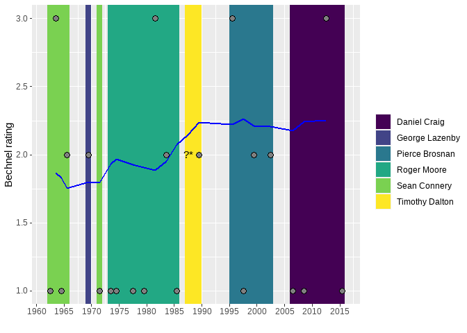

```r
ggplot() +
  #Adjust the location so that movies fall in the middle of a year rather than at the start
  geom_rect(data = bond_eras_startend, aes(xmin = start, xmax = end + 1, ymin = -Inf, ymax = Inf, fill = as.factor(actor)),
            colour = NA) +
  geom_path(data = combo_data, aes(x = year + 0.5, y = rollingmean_allmovies), size = 1, colour = "blue") +
  geom_point(data = bond_movies, aes(x = year + 0.5, y = bond_rating), size = 3, shape = 21, fill = "grey50") +
  #Add ? for Living daylights
  geom_text(aes(x = 1987 + 0.5, y = 2, label = "?*")) +
  scale_fill_viridis_d(name = "") +
  scale_x_continuous(breaks = seq(1960, 2020, 5), name = "") +
  scale_y_continuous(name = "Bechnel rating")
```

This is all good and well, but it’s hard to read anything due to the ordinal nature of the data. Determine a mean rating value for each actor instead.

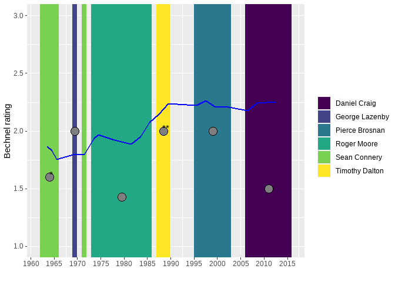

```r
bond_era_ratings <- bond_movies %>%
  group_by(Actor) %>%
  summarise(mean_rating = mean(bond_rating, na.rm = TRUE),
            middle_yr = (first(year) + last(year))/2)

#Change Connery middle period to be in first era
bond_era_ratings$middle_yr[bond_era_ratings$Actor == "Sean Connery"] <- 1963.5

ggplot() +
  #Adjust the location so that movies fall in the middle of a year rather than at the start
  geom_rect(data = bond_eras_startend, aes(xmin = start, xmax = end + 1, ymin = -Inf, ymax = Inf, fill = as.factor(actor)),
            colour = NA) +
  geom_path(data = combo_data, aes(x = year + 0.5, y = rollingmean_allmovies), size = 1, colour = "blue") +
  geom_point(data = bond_era_ratings, aes(x = middle_yr + 0.5, y = mean_rating), size = 5, shape = 21, fill = "grey50") +
  #Add * next to Connery and Dalton
  geom_text(data = filter(bond_era_ratings, Actor %in% c("Sean Connery", "Timothy Dalton")),
            aes(x = middle_yr + 0.9, y = mean_rating + 0.025, label = c("*", "**"))) +
  scale_fill_viridis_d(name = "") +
  scale_x_continuous(breaks = seq(1960, 2020, 5), name = "") +
  scale_y_continuous(name = "Bechnel rating", limits = c(1, 3))
```

Again fine, but it has a few problems:

1. What to do with years where there were no Bond movies? Can leave blank to show the change over time in all movies but this feels like empty space for our purposes.
2. How to deal with Connery/Lazenby overlap?

Instead, we can make the x-axis time in number of movies (instead of years). We need data which includes: - Mean rating of bond movies per bond - Start and end year of movie ‘run’ - Start and end of movie ‘run’ based on position in the bond universe - Length of movie run (i.e. number of films) - Mean Bechdel test rating for all other movies during this run (including years without any movies)

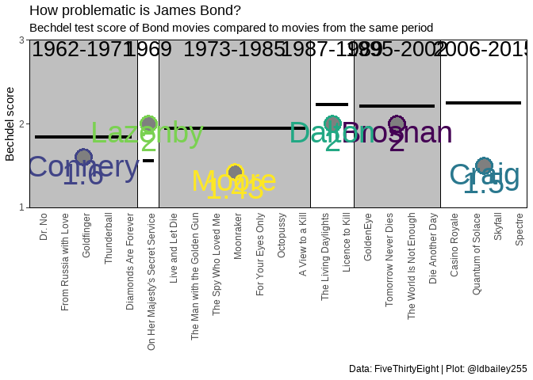

```r
other_movies <- bechdel %>%
  dplyr::left_join(dplyr::select(movies, imdb_id, genre, language), by = "imdb_id") %>%
  fuzzyjoin::stringdist_anti_join(bond, by = c("title" = "Movie")) %>%
  dplyr::filter(year %in% bond_movies$year)

bond_era_ratings <- bond_movies %>%
  tibble::rownames_to_column(var = "movie_nr") %>%
  #Change the 'order' of the Connery and Lazenby movies so they're sequential
  mutate(movie_nr = c(1:4, 6, 5, 7:23)) %>%
  tidyr::separate(Actor, into = c("given_name", "surname"), sep = " ") %>%
  group_by(surname) %>%
  summarise(mean_bond_rating = mean(bond_rating, na.rm = TRUE),
            first_yr = first(year),
            first_nr = as.integer(first(movie_nr)) - 0.5,
            last_yr = last(year),
            last_nr = as.integer(last(movie_nr)) + 0.5,
            middle_point = mean(c(first_nr, last_nr)),
            nr_movies = n()) %>%
  mutate(mean_movie_rating = purrr::map2_dbl(.x = first_yr, .y = last_yr,
                                             .f = function(first, last, movie_db){

                                               movie_db_subset <- other_movies %>%
                                                 filter(year >= first & year <= last)

                                               mean(movie_db_subset$rating)

                                             }, movie_db = other_movies),
         year_text = case_when(first_yr == last_yr ~ as.character(first_yr),
                               TRUE ~ paste(first_yr, last_yr, sep = "-")))

x_labels <- bond_movies %>%
  tibble::rownames_to_column(var = "movie_nr") %>%
  #Change the 'order' of the Connery and Lazenby movies so they're sequential
  mutate(movie_nr = c(1:4, 6, 5, 7:23)) %>%
  arrange(movie_nr) %>%
  pull(title)

ggplot(data = bond_era_ratings) +
  geom_rect(aes(xmin = first_nr, xmax = last_nr, ymin = -Inf, ymax = Inf, fill = surname),
            colour = "black", alpha = 0.5) +
  geom_segment(aes(x = first_nr + 0.25, xend = last_nr - 0.25, y = mean_movie_rating, yend = mean_movie_rating), size = 1.5) +
  geom_text(aes(x = middle_point, y = 2.9, label = year_text),
            size = 7) +
  geom_point(aes(x = middle_point, y = mean_bond_rating, colour = surname),
             size = 6, shape = 21, stroke = 2, fill = "grey50") +
  geom_text(aes(x = middle_point, y = mean_bond_rating - 0.1, colour = surname,
                label = surname), size = 10) +
  geom_text(aes(x = middle_point, y = mean_bond_rating - 0.2, colour = surname,
                label = round(mean_bond_rating, 2)), size = 10) +
  scale_x_continuous(breaks = seq(1, 23, 1), labels = x_labels) +
  scale_y_continuous(limits = c(1, 3), breaks = 1:3) +
  scale_fill_manual(values = c("grey50", "grey50", NA, NA, NA, "grey50"), name = "") +
  scale_colour_viridis_d(name = "") +
  labs(x = "", y = "Bechdel score",
       title = "How problematic is James Bond?",
       subtitle = "Bechdel test score of Bond movies compared to movies from the same period",
       caption = "Data: FiveThirtyEight | Plot: @ldbailey255") +
  coord_cartesian(expand = FALSE) +
  theme_classic() +
  theme(legend.position = "none",
        axis.text.x = element_text(angle = 90, hjust = 1, vjust = 1),
        axis.ticks.x = element_blank(),
        axis.line.x = element_blank())
```

Add the actor images instead of points

[figure not shown]

```r
all_png <- data.frame(file = list.files(here::here("./inst/extdata/bonds"), pattern = ".png", full.names = TRUE)) %>%
  mutate(surname = stringr::str_to_title(stringr::str_sub(basename(file), end = -5))) %>%
  rowwise() %>%
  mutate(grob = list(grid::rasterGrob(png::readPNG(source = file),
                                      width = unit(3, "cm"), height = unit(3, "cm"))))

bond_era_ratings_png <- bond_era_ratings %>%
  left_join(all_png, by = "surname")

ggplot(data = bond_era_ratings_png) +
  geom_rect(aes(xmin = first_nr, xmax = last_nr, ymin = -Inf, ymax = Inf, fill = surname),
            colour = "black", alpha = 0.5) +
  geom_segment(aes(x = first_nr + 0.25, xend = last_nr - 0.25, y = mean_movie_rating, yend = mean_movie_rating), size = 1.5) +
  geom_text(aes(x = middle_point, y = 2.9, label = year_text),
            size = 7) +
  # geom_point(aes(x = middle_point, y = mean_bond_rating, colour = surname),
  #            size = 10, shape = 21, stroke = 2, fill = "grey50") +
  # geom_text(aes(x = middle_point, y = mean_bond_rating - 0.1, colour = surname,
  #               label = surname), size = 10) +
  geom_text(aes(x = middle_point, y = mean_bond_rating - 0.2,
                label = round(mean_bond_rating, 2)), size = 10) +
  egg::geom_custom(aes(x = middle_point, y = mean_bond_rating, data = grob), grob_fun = "identity") +
  scale_x_continuous(breaks = seq(1, 23, 1), labels = x_labels) +
  scale_y_continuous(limits = c(1, 3), breaks = 1:3) +
  scale_fill_manual(values = c("grey50", "grey50", NA, NA, NA, "grey50"), name = "") +
  scale_colour_viridis_d(name = "") +
  labs(x = "", y = "Bechdel score",
       title = "How problematic is James Bond?",
       subtitle = "Bechdel test score of Bond movies compared to movies from the same period",
       caption = "Data: FiveThirtyEight | Plot: @ldbailey255") +
  coord_cartesian(expand = FALSE) +
  theme_classic() +
  theme(legend.position = "none",
        axis.text.x = element_text(angle = 90, hjust = 1, vjust = 1),
        axis.ticks.x = element_blank(),
        axis.line.x = element_blank())
```

```r
ggsave(filename = here::here("./plots/2021/Week11/2021Week11.png"), height = 14, width = 18, dpi = 600, scale = 0.75)
```

Make it pretty

```r
#Load a font from Google Fonts
sysfonts::font_add_google(name = "Mouse Memoirs", family = "Mouse")
sysfonts::font_add_google("Ubuntu Mono", "Ubuntu Mono")

#Specify that the showtext package should be used
#for rendering text
showtext::showtext_auto()
```

[figure not shown]

```r
all_png <- data.frame(file = list.files(here::here("./inst/extdata/bonds"), pattern = ".png", full.names = TRUE)) %>%
  mutate(surname = stringr::str_to_title(stringr::str_sub(basename(file), end = -5))) %>%
  rowwise() %>%
  mutate(grob = list(grid::rasterGrob(png::readPNG(source = file),
                                      width = unit(2, "cm"), height = unit(2, "cm"))))

bond_era_ratings_png <- bond_era_ratings %>%
  left_join(all_png, by = "surname")

ggplot(data = bond_era_ratings_png) +
  geom_rect(aes(xmin = first_nr, xmax = last_nr, ymin = -Inf, ymax = Inf, fill = surname),
            colour = "black", alpha = 0.5) +
  geom_segment(aes(x = first_nr + 0.25, xend = last_nr - 0.25, y = mean_movie_rating, yend = mean_movie_rating), size = 3) +
  # geom_segment(aes(x = middle_point, xend = middle_point, y = mean_movie_rating, yend = mean_bond_rating), size = 3) +
  geom_text(aes(x = middle_point, y = 2.9, label = year_text),
            size = 34, family = "Mouse") +
  geom_text(aes(x = middle_point, y = mean_bond_rating - 0.2,
                label = surname), size = 40, family = "Mouse", colour = "#482677FF") +
  geom_text(aes(x = middle_point, y = mean_bond_rating - 0.275,
                label = round(mean_bond_rating, 2)), size = 40, family = "Mouse") +
  egg::geom_custom(aes(x = middle_point, y = mean_bond_rating, data = grob), grob_fun = "identity") +
  scale_x_continuous(breaks = seq(1, 23, 1), labels = x_labels) +
  scale_y_continuous(limits = c(1, 3), breaks = 1:3) +
  scale_fill_manual(values = c("grey50", "grey50", NA, NA, NA, "grey50"), name = "") +
  scale_colour_viridis_d(name = "") +
  labs(x = "", y = "<- Worse                       Bechdel score                       Better ->",
       title = "How problematic is James Bond?",
       subtitle = "Bechdel test score of Bond movies compared to movies from the same period",
       caption = "Data: FiveThirtyEight | Plot: @ldbailey255") +
  coord_cartesian(expand = FALSE) +
  theme_classic() +
  theme(legend.position = "none",
        axis.text.x = element_text(angle = 90, hjust = 1, vjust = 1, size = 100,
                                   family = "Mouse", colour = "black"),
        axis.text.y = element_text(size = 100, family = "Mouse", colour = "black"),
        axis.ticks.x = element_blank(),
        axis.line.x = element_blank(),
        axis.title = element_text(size = 140, family = "Mouse"),
        plot.title = element_text(size = 160, family = "Mouse"),
        plot.subtitle = element_text(size = 70),
        plot.caption = element_text(size = 50))
```

```r
ggsave(filename = here::here("./plots/2021/Week11/2021Week11.png"), height = 14, width = 18, dpi = 600, scale = 1)
```